# Framanburdur

## Gagna Innlestur

Lesið er inn gögninn

```r
hashAnswer <- read.csv('Data/hashAnswer4.csv')
hashAnswer <- hashAnswer %>% subset(select=-c(X))
hashAnswer$hsta <- hashAnswer$hsta%>%as.character()
hashAnswer$lectureId <- hashAnswer$lectureId %>% as.factor()
hashAnswer$studentId <- hashAnswer$studentId %>% as.factor()
hashAnswer$nicc <- hashAnswer$nicc %>% as.factor()
hashAnswer$fsfat <- hashAnswer$fsfat/10
hashAnswer$fsvfatu <- hashAnswer$fsvfatu/10
hashAnswer$gpow2 <- as.factor(floor(log2(hashAnswer$gpow)))
```

Þetta eru tutor-web gögn fyrir lík og töl í vormisseri 2020.

```r
glimpse(hashAnswer)
```

```
## Rows: 115,197
## Columns: 14
## $ timeStart  <chr> "2020-01-15 10:24:32", "2020-01-15 10:26:20", "2020-01-1...
## $ lectureId  <fct> 3082, 3082, 3082, 3082, 3082, 3082, 3082, 3082, 3082, 30...
## $ studentId  <fct> 1, 1, 1, 1, 1, 18788, 18788, 18788, 18788, 18788, 18788,...
## $ questionId <int> 45591, 44899, 45647, 45647, 45647, 44920, 45021, 45480, ...
## $ correct    <int> 0, 1, 0, 0, 0, 1, 0, 1, 1, 0, 0, 1, 1, 0, 0, 0, 0, 0, 1,...
## $ hash       <chr> "d3a978206c877eee8627a29c7a94238d8339d66fc4be460d9e6b6cb...
## $ fsfat      <dbl> 0.0, 0.1, 0.2, 0.2, 0.2, 0.0, 0.1, 0.2, 0.3, 0.4, 0.5, 0...
## $ fsvfat     <int> 0, 1, 2, 3, 4, 0, 1, 2, 3, 4, 5, 5, 6, 7, 8, 9, 10, 11, ...
## $ fsvfatu    <dbl> 0.0, 0.1, 0.2, 0.2, 0.2, 0.0, 0.1, 0.2, 0.3, 0.4, 0.5, 0...
## $ hsta       <chr> "0", "0", "0", "0", "0", "0", "0", "0", "0", "0", "0", "...
## $ timeDif    <int> NA, NA, NA, NA, NA, NA, NA, NA, NA, NA, NA, 254, NA, NA,...
## $ nicc       <fct> 3, 3, 3, 3, 3, 3, 7, 3, 3, 4, 5, 6, 6, 5, 3, 3, 3, 3, 7,...
## $ gpow       <dbl> 8.2506619, 8.2506619, 8.2506619, 8.2506619, 8.2506619, 0...
## $ gpow2      <fct> 3, 3, 3, 3, 3, -2, -2, -2, -2, -2, -2, -2, -2, -2, -2, -...
```

Fyrsta sem ég gerði var að skoða aðeins einföld logistic regression föll, skipt upp eftir því hve margar spurningar, semsagt fsfat ég leifi að svara. Þá fyrir fsfat og fyrir fsvfat, byrjandi með því að skoða fsfat

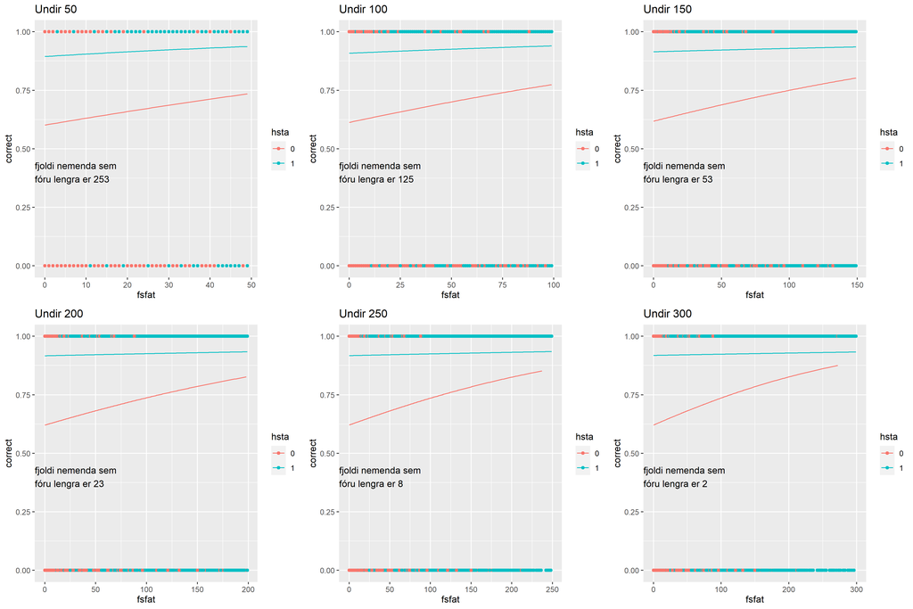

Svo fyrir fsvfat

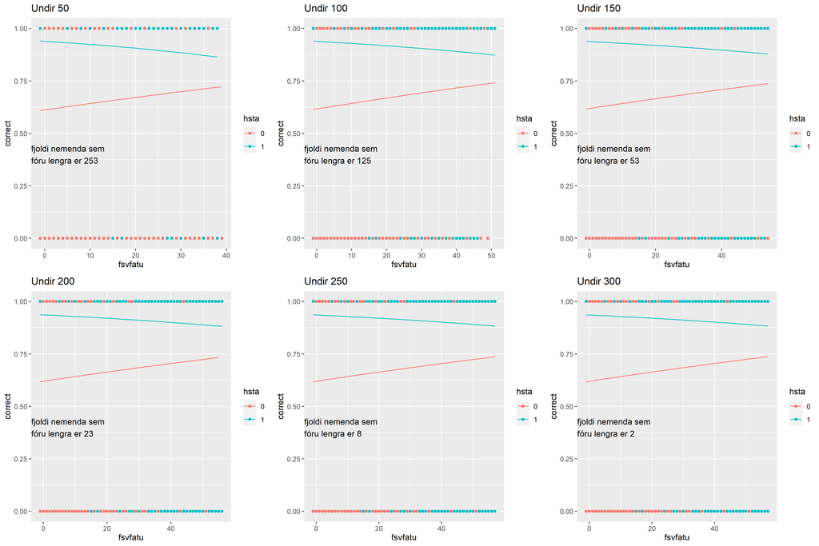

Nú líkanið sem er notað hér er einfalt glm(correct ~ fsfat*hsta) og glm(correct ~ fsvfat*hsta). Semsagt $p_i = H(\beta_0 + fsfat\beta_1+fsfat*hsta*\beta_2+hsta\beta_3)$ og $p_i = H(\beta_0 + fsvfat\beta_1+fsvfat*hsta*\beta_2+hsta\beta_3)$, þar sem $H$ er logistic link fallið. (Vantar enn upplýsingar sem ég mun skrifa meira um þegar þörf er, t.d. það að við erum með $p_i$ en ég merki ekki $fsfat$ með $fsfat_i$)

Þegar skoðað er yfir myndirnar, fyrst fyrir fsfat. Þá ef nemandinn hefur ekki séð spurningunna áður, þá lítur út fyrir að vera að vaxa líkurnar á að nemandinn fær svarið rétt, en það lítur út fyrir að því fleiri svör við skoðum, því hægari línunar vaxa, sést við þegar við skoðum hvar línan er við 50 í hvert skipti, það minnkar og minnkar. þegar nemandinn hefur séð svarið áður, þá hefur vaxinn minni og minni vaxa líka, og verður eins og bein lína að seinast grafinu. Gæti verið góð hugmynd að skoða graf þar sem tekið eru allar línu og sett á sama grafið. Prufa það seinna. Nú, ef horft er á allar línurnar í einu þegar spurningin er ný þá fæst

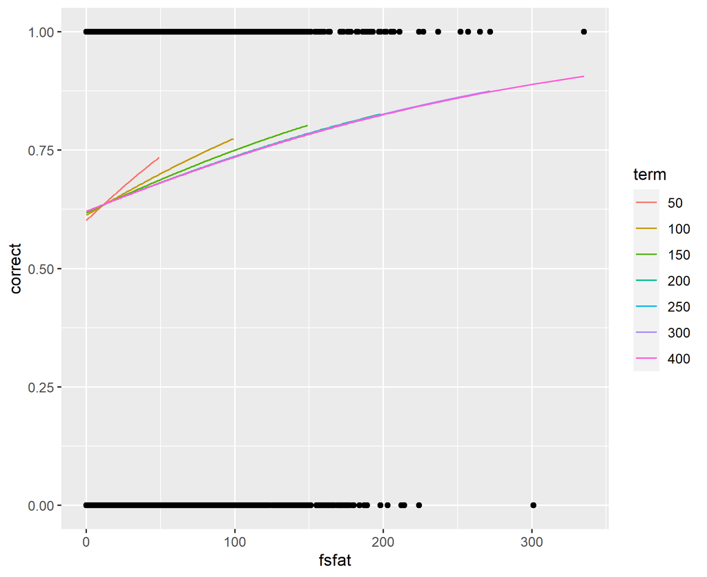

Hér sést að hallin minnkar því fleiri spurnigar eru spyrðar, hmmmm.

Næst Þegar það er skoðað með tilliti til fsvfat, fyrsta sem maður tekur eftir, er að líkurnar að fá rétt svar, eftir því hve mikið af svörum hefur sést hingað til er að minnka miðað við þetta líkann, svo nemandinn verður aðeins verra af með spurningum í því tilviki. Á meðan fyrir þær spurningar sem eru að sjást í fyrsta skiptið er að vaxa eins og var verið að búast við. Lítur út fyrir að þegar fleiri spurningar eru leifðar að svara, þá vex slope-ið hjá svörunum sem hafa sést áður aðeins upp, á meðan fyrir þær sem eru að koma í fyrsta sinn er ekki of mikil breyting á milli. Afhverju er svona minni breyting hjá fsvfat miðað við fsfat? Þetta hefur líklega að gera við það að þeir sem eru að svara rosalega mikið eru ekki að toga línuna of mikið með hugsa ég.

Nú þetta sýnir aðallega smá meiri vaxta, en fyrir spurningunna “Er hægt að mæla framfarir en ekki bara utanaðbókarlærdóm? Bera saman fyrstu svarmöguleika og þá sem hafa komið áður” þá er sést að það eru framfarir þegar svarið kemur fyrst eftir því lengra sem er komið, en að mínu mati er ekki komið með það hvort þetta eru framfarir eða utanbókarlærdómur, þar sem ekki er innifalið röngu svörinn ennþá, því ekki er vitað hvort nemandinn er að ná beinum framförum í nýju spurningunum, eða hvort þetta er það að nemandinn er að setja á minnið röngu svörinn og þá er vöxturinn utanaðbókarlærdómur. hmmmmmm

Eftir þessar teikningar skoðaði ég aðeins meðaltölinn fyrir hvert fsfat og fsvfat og plottaði þau. Hlið er svo fjöldi nemenda sem eru ennþá að gera dæminn

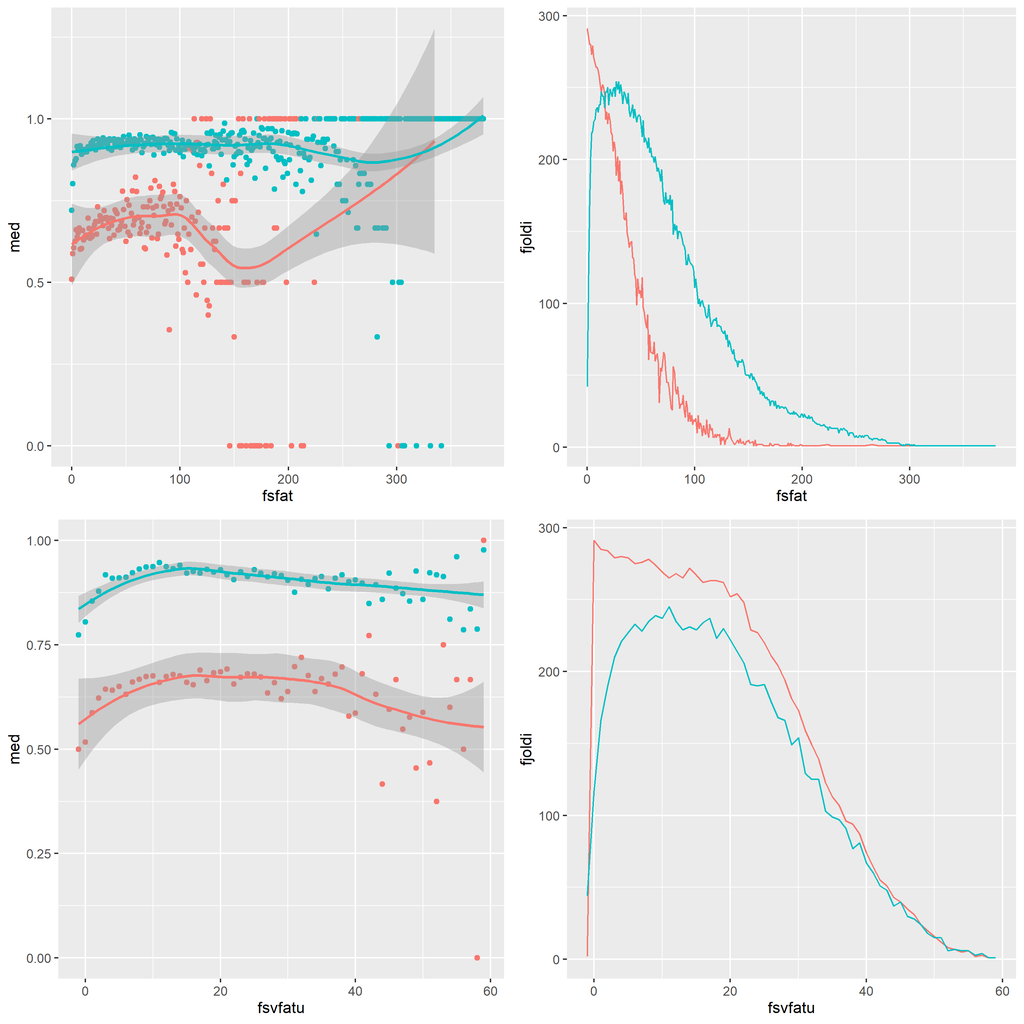

Nú, það sést að í báðum tilvikum, þá gerist tvennt hjá svörunum sem er að komast í fyrsta sinn, fyrst er að dreifinginn lítur út fyrir að stækka með tímanum, næst er að það er eitthvað fall sem kemur hjá þeim. Ég er með hugmynd um ástæðurnar, en ekkert fast. Fyrir fyrsta þá er dreifingin að stækka líklegast því að það eru minni gögn til að vinna með því lengra sem er farið, svo dreifingin stækkar því að þakka. Næst er að þegar nemendur hafa verið að svara svona mörgum spurningu, t.d. 100+, þá eru þau líklega byrjuð að flýta sér og því ekki eitt nógum tíma í hvert. Getum skoðað sömu myndir fyrir minni hópa og séð hvort það hefur áhrif

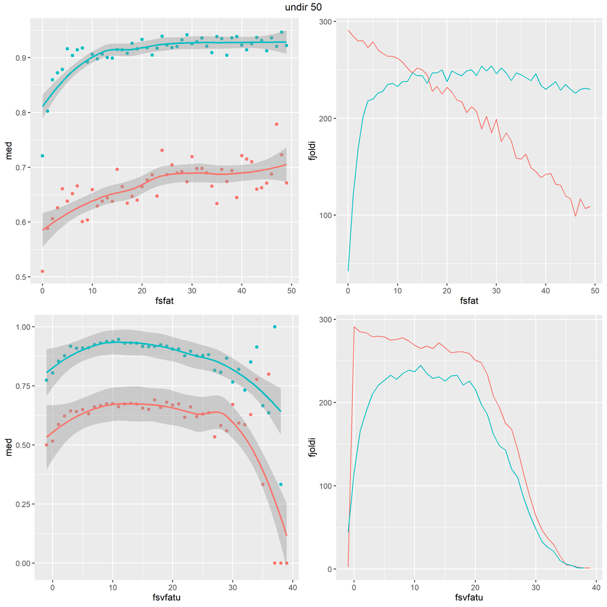

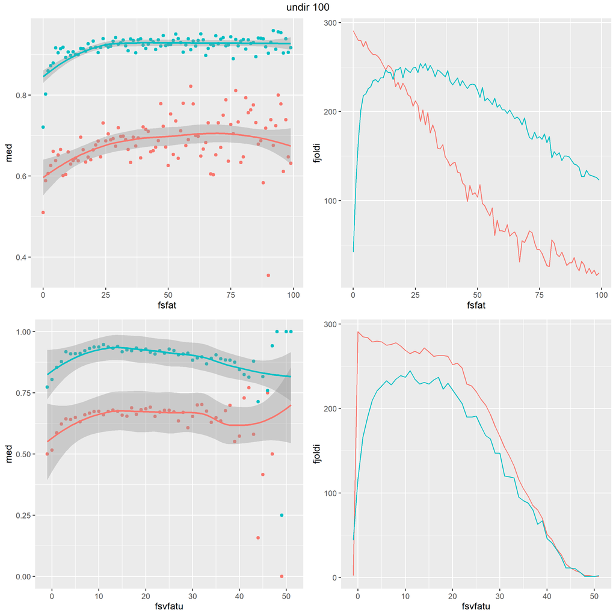

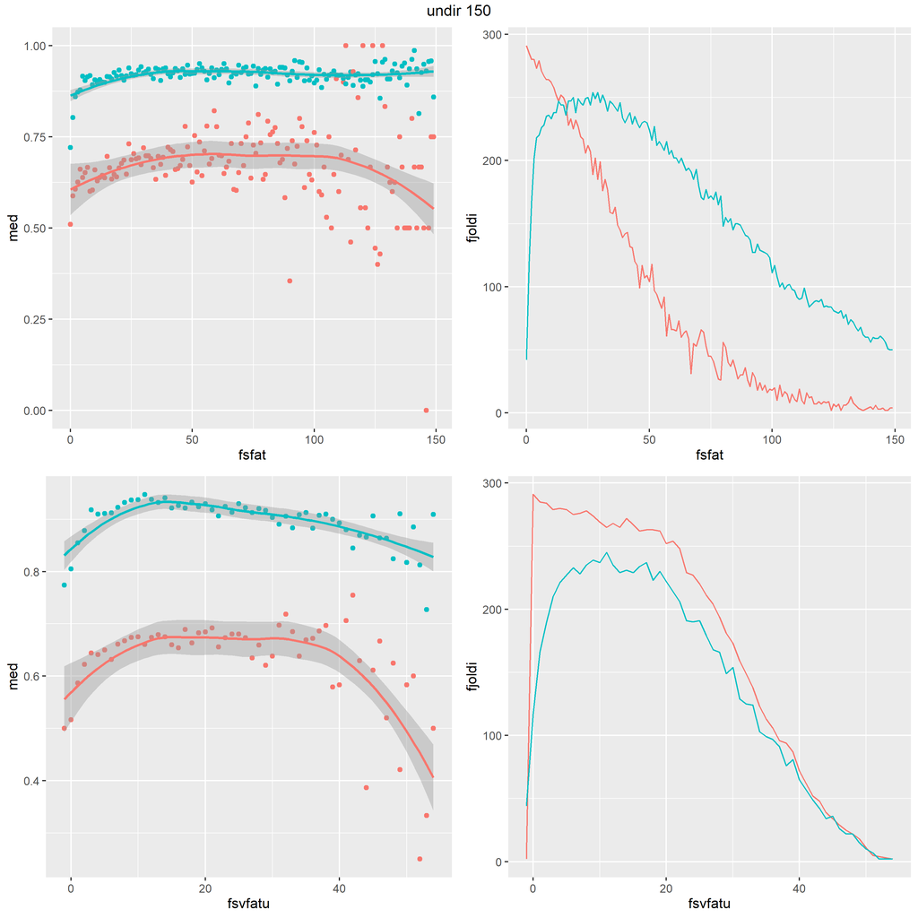

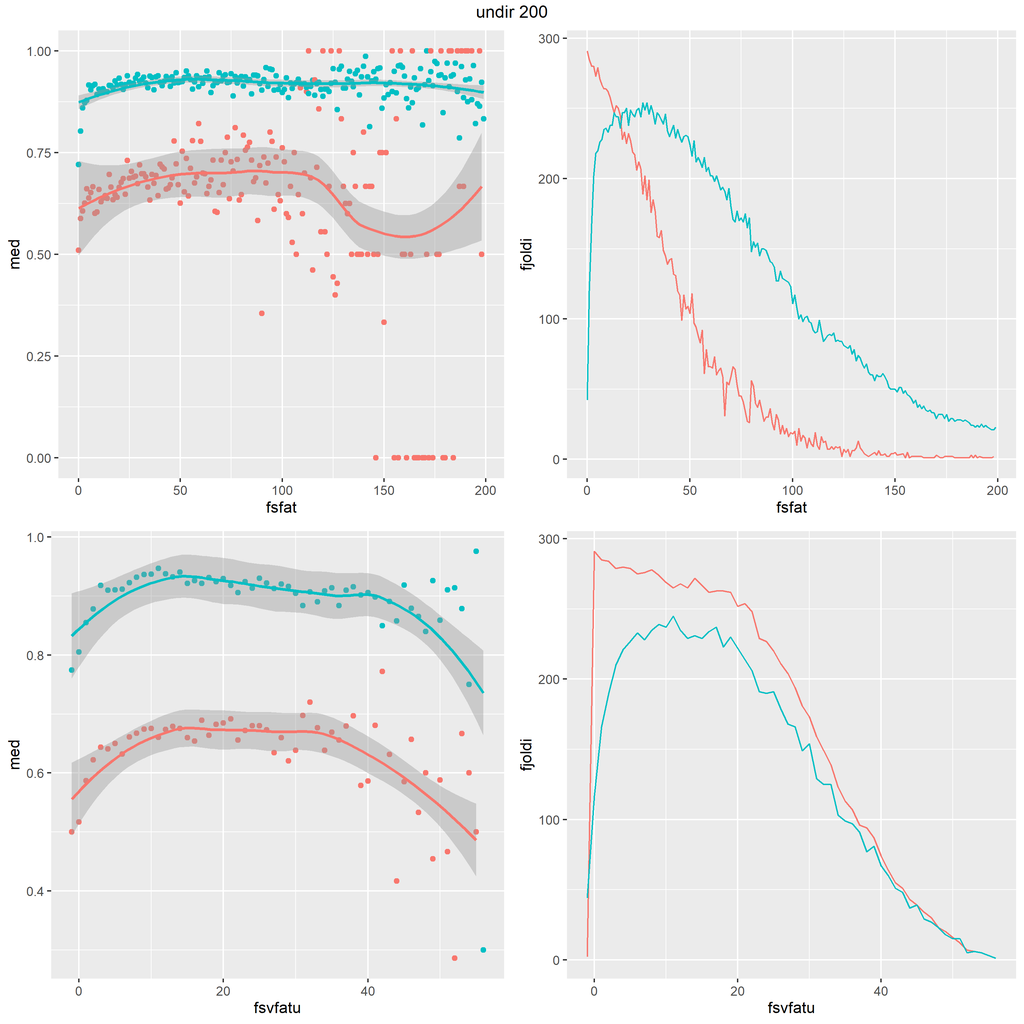

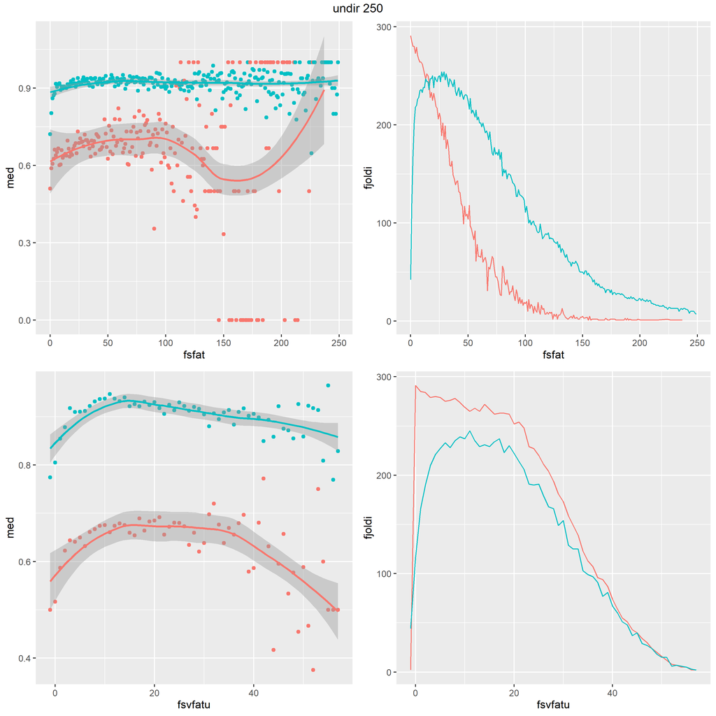

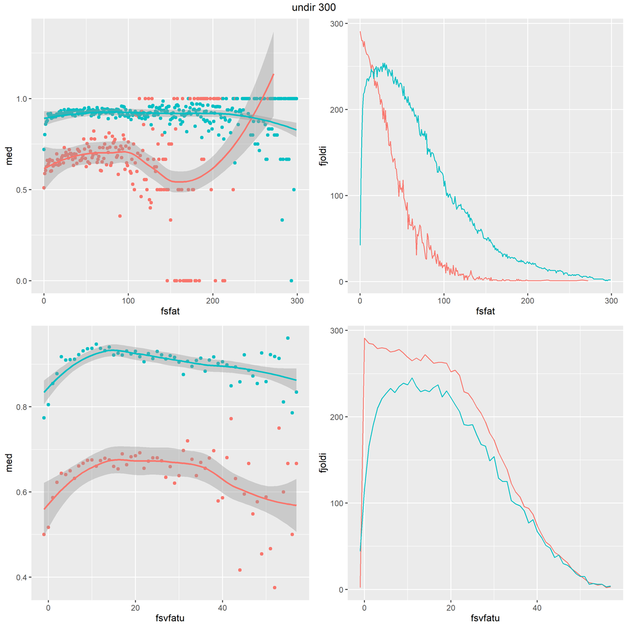

Sér smá hvar allt er að detta og stökkva aftur upp, en ekki alveg viss hvort það er eitthvað mikilvægt í myndunum þarna. Svo að lokum skoðaði ég aðeins logistic regression föllin aftur, en skipt upp eftir lectureId og studentId

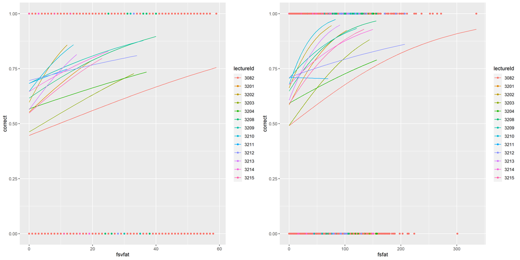

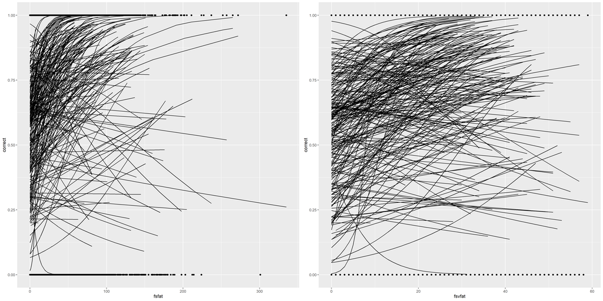

Það lýtur út fyrir að vera munur milli nemenda og fyrirlesturs, en frá ábendingu þá gæti það verið gotta að skoða aðeins flóknari model með mixed effect, þar sem observation-in eru ekki óháð hvort öðru, en eru háð nemenda til nemenda. Skoða aðeins betur seinna með glmer.

Eftir allar þessa myndir, þá gæti verið gotta að skoða einhverjar töflur um gögninn, svo ég setti upp einhverjar til að skoða það allt, fyrsta taflan hérna er að skoða hve mikið og hvert hlutfallið er af gögnunum sem eru nemendur að fara yfir x mörg svör fyrir hvern fyrirlestur. Nota aðallega til að vita hvar það gæti verið gott að skera gögninn, óþarfi að nota öll svörinn

```r
hashAnswer %>% group_by(lectureId) %>% summarise("FY50" = sum(fsfat >= 5), "HY50" = mean(fsfat > 5),
                                                 "FY100" = sum(fsfat >= 10), "HY100" = mean(fsfat > 10),
                                                 "FY150" = sum(fsfat >= 15), "HY150" = mean(fsfat > 15),
                                                 "FY200" = sum(fsfat >= 20), "HY200" = mean(fsfat > 20),
                                                 "FY250" = sum(fsfat >= 25), "HY250" = mean(fsfat > 25),
                                                 "FY300" = sum(fsfat >= 30), "HY300" = mean(fsfat > 30)) %>% kable(digits = 4)
```

| lectureId | FY50 | HY50 | FY100 | HY100 | FY150 | HY150 | FY200 | HY200 | FY250 | HY250 | FY300 | HY300 |
| --- | --- | --- | --- | --- | --- | --- | --- | --- | --- | --- | --- | --- |
| 3082 | 14087 | 0.5267 | 6251 | 0.2334 | 2517 | 0.0936 | 960 | 0.0357 | 278 | 0.0103 | 80 | 3e-03 |
| 3201 | 1183 | 0.1384 | 66 | 0.0076 | 0 | 0.0000 | 0 | 0.0000 | 0 | 0.0000 | 0 | 0e+00 |
| 3202 | 360 | 0.0639 | 0 | 0.0000 | 0 | 0.0000 | 0 | 0.0000 | 0 | 0.0000 | 0 | 0e+00 |
| 3203 | 3528 | 0.2700 | 667 | 0.0512 | 184 | 0.0143 | 104 | 0.0082 | 54 | 0.0042 | 4 | 2e-04 |
| 3204 | 2810 | 0.2607 | 743 | 0.0695 | 109 | 0.0098 | 0 | 0.0000 | 0 | 0.0000 | 0 | 0e+00 |
| 3208 | 1878 | 0.2253 | 279 | 0.0333 | 53 | 0.0063 | 0 | 0.0000 | 0 | 0.0000 | 0 | 0e+00 |
| 3209 | 1391 | 0.1947 | 158 | 0.0218 | 0 | 0.0000 | 0 | 0.0000 | 0 | 0.0000 | 0 | 0e+00 |
| 3210 | 519 | 0.0920 | 3 | 0.0004 | 0 | 0.0000 | 0 | 0.0000 | 0 | 0.0000 | 0 | 0e+00 |
| 3211 | 490 | 0.0901 | 6 | 0.0010 | 0 | 0.0000 | 0 | 0.0000 | 0 | 0.0000 | 0 | 0e+00 |
| 3212 | 2069 | 0.2705 | 715 | 0.0938 | 222 | 0.0291 | 74 | 0.0097 | 0 | 0.0000 | 0 | 0e+00 |
| 3213 | 1061 | 0.1554 | 155 | 0.0225 | 1 | 0.0000 | 0 | 0.0000 | 0 | 0.0000 | 0 | 0e+00 |
| 3214 | 1175 | 0.1807 | 225 | 0.0349 | 62 | 0.0097 | 0 | 0.0000 | 0 | 0.0000 | 0 | 0e+00 |
| 3215 | 1413 | 0.1985 | 285 | 0.0404 | 56 | 0.0080 | 11 | 0.0015 | 0 | 0.0000 | 0 | 0e+00 |

Nú er FYx fjöldi gagna yfir x og HYx hlutfall gagna yfir x. Gott væri að skoða sitthvort sem væri þá til að sjá það aðeins betur beint

```r
hashAnswer %>% group_by(lectureId) %>% summarise("FY50" = sum(fsfat >= 5), "FY100" = sum(fsfat >= 10),
                                                 "FY150" = sum(fsfat >= 15), "FY200" = sum(fsfat >= 20),
                                                 "FY250" = sum(fsfat >= 25), "FY300" = sum(fsfat >= 30)) %>%
  kable(digits = 4)
```

| lectureId | FY50 | FY100 | FY150 | FY200 | FY250 | FY300 |
| --- | --- | --- | --- | --- | --- | --- |
| 3082 | 14087 | 6251 | 2517 | 960 | 278 | 80 |
| 3201 | 1183 | 66 | 0 | 0 | 0 | 0 |
| 3202 | 360 | 0 | 0 | 0 | 0 | 0 |
| 3203 | 3528 | 667 | 184 | 104 | 54 | 4 |
| 3204 | 2810 | 743 | 109 | 0 | 0 | 0 |
| 3208 | 1878 | 279 | 53 | 0 | 0 | 0 |
| 3209 | 1391 | 158 | 0 | 0 | 0 | 0 |
| 3210 | 519 | 3 | 0 | 0 | 0 | 0 |
| 3211 | 490 | 6 | 0 | 0 | 0 | 0 |
| 3212 | 2069 | 715 | 222 | 74 | 0 | 0 |
| 3213 | 1061 | 155 | 1 | 0 | 0 | 0 |
| 3214 | 1175 | 225 | 62 | 0 | 0 | 0 |
| 3215 | 1413 | 285 | 56 | 11 | 0 | 0 |

```r
hashAnswer %>% group_by(lectureId) %>% summarise("HY50" = mean(fsfat >= 5), "HY100" = mean(fsfat >= 10),
                                                 "HY150" = mean(fsfat >= 15), "HY200" = mean(fsfat >= 20),
                                                 "HY250" = mean(fsfat >= 25), "HY300" = mean(fsfat >= 30)) %>%
  kable(digits = 4)
```

| lectureId | HY50 | HY100 | HY150 | HY200 | HY250 | HY300 |
| --- | --- | --- | --- | --- | --- | --- |
| 3082 | 0.5349 | 0.2374 | 0.0956 | 0.0365 | 0.0106 | 3e-03 |
| 3201 | 0.1451 | 0.0081 | 0.0000 | 0.0000 | 0.0000 | 0e+00 |
| 3202 | 0.0683 | 0.0000 | 0.0000 | 0.0000 | 0.0000 | 0e+00 |
| 3203 | 0.2798 | 0.0529 | 0.0146 | 0.0082 | 0.0043 | 3e-04 |
| 3204 | 0.2687 | 0.0710 | 0.0104 | 0.0000 | 0.0000 | 0e+00 |
| 3208 | 0.2327 | 0.0346 | 0.0066 | 0.0000 | 0.0000 | 0e+00 |
| 3209 | 0.2019 | 0.0229 | 0.0000 | 0.0000 | 0.0000 | 0e+00 |
| 3210 | 0.0983 | 0.0006 | 0.0000 | 0.0000 | 0.0000 | 0e+00 |
| 3211 | 0.0966 | 0.0012 | 0.0000 | 0.0000 | 0.0000 | 0e+00 |
| 3212 | 0.2784 | 0.0962 | 0.0299 | 0.0100 | 0.0000 | 0e+00 |
| 3213 | 0.1632 | 0.0238 | 0.0002 | 0.0000 | 0.0000 | 0e+00 |
| 3214 | 0.1874 | 0.0359 | 0.0099 | 0.0000 | 0.0000 | 0e+00 |
| 3215 | 0.2062 | 0.0416 | 0.0082 | 0.0016 | 0.0000 | 0e+00 |

fyrir alla fyrirlestrana nema 3082 þá eru u.þ.b. 70% af gögnunum undir 50 spurningum svarað, en það er í kringum undir 100 fyrir 3082, svo fleiri spurningum er svarað eftir þá. Spurning hvort þetta kemur frá fáum nemendum sem eru að svara miklu meira en hinir.

Svo að lokum fjöldann og hlutfall yfir x fyrir öll gögninn, ekki bara fyrir hvern fyrirlestur fyrir sig

```r
a <- hashAnswer %>% summarise("FY50" = sum(fsfat >= 5), "FY100" = sum(fsfat >= 10),
                              "FY150" = sum(fsfat >= 15), "FY200" = sum(fsfat >= 20),
                              "FY250" = sum(fsfat >= 25), "FY300" = sum(fsfat >= 30))
b <- hashAnswer %>% summarise("HY50" = mean(fsfat >= 5), "HY100" = mean(fsfat >= 10),
                              "HY150" = mean(fsfat >= 15), "HY200" = mean(fsfat >= 20),
                              "HY250" = mean(fsfat >= 25), "HY300" = mean(fsfat >= 30))
ab <- cbind(a, b)
FHbylim <- ab %>% pivot_longer(c('FY50', 'HY50', 'FY100', 'HY100', 'FY150', 'HY150', 'FY200', 'HY200', 'FY250', 'HY250', 'FY300', 'HY300'),
                    names_to = "typewLim", values_to = "values") %>%
  separate(typewLim, into = c("type", "limit"), sep = 2) %>% pivot_wider(names_from = type, values_from = values)


FHbylim %>% kable(digits = 4)
```

| limit | FY | HY |
| --- | --- | --- |
| 50 | 31964 | 0.2775 |
| 100 | 9553 | 0.0829 |
| 150 | 3204 | 0.0278 |
| 200 | 1149 | 0.0100 |
| 250 | 332 | 0.0029 |
| 300 | 84 | 0.0007 |

Lítur út að fyrir heildina þá er 27.75% af gögnunum sem eru svör eftir fyrstu 50, svo bara 8.29% af gögnunum sem eru svör eftir fyrstu 100. Kannski gott að skera þá hjá 100. Mun byrja með það

Næst gæti það verið gott að skoða aðeins hlutfall svara sem hafa sést áður og svo fjölda og hlutföll þeirra sem eru rétt eða röng af því. Byrja með hlutfall hsta við mynd

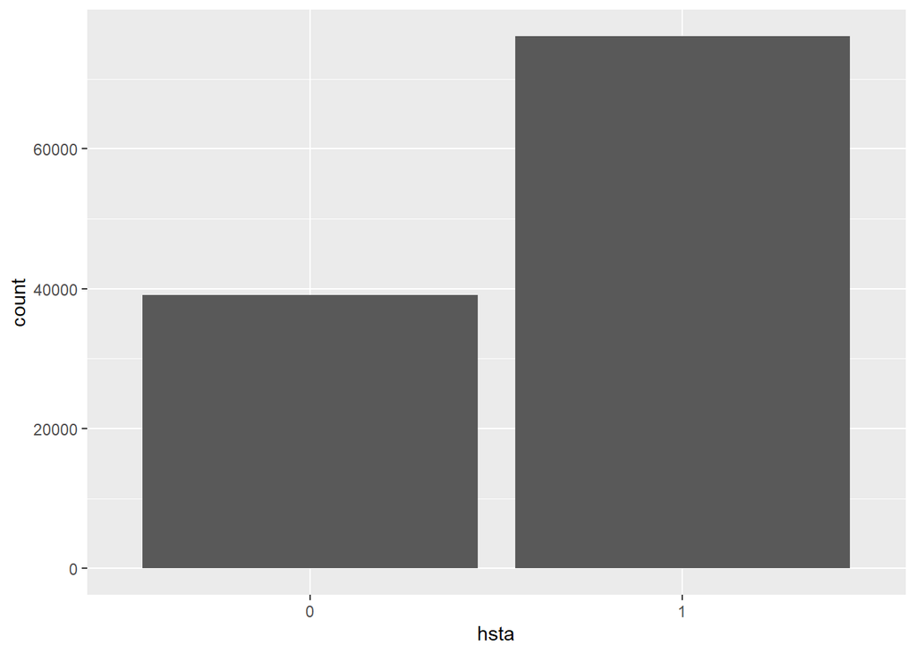

```r
ggplot(hashAnswer, aes(x = hsta)) +
  geom_bar()
```

Lítur út fyrir að um 2/3 allra gagnanna er verið að svara þegar nemandinn hefur séð svarið áður, hugmynd kannski að skoða þetta betur með minni gögn? hmmmmmmmmmm

skoðum svo aðeins hlutföllin beint fyrir rétt svör, hvort þau hafa séð þetta áður og svo hlutföllin af svörunum sem eru svo innan hvern flokks

```r
correctnam <- ifelse(hashAnswer$correct == 0, "Vitlaust", "Rétt")
hstanam <- ifelse(hashAnswer$hsta == "0", "Nýtt", "Hef séð áður")
corhsta <- prop.table(table(hashAnswer$correct+1, hashAnswer$hsta ))
corhsta <- rbind(corhsta, c(sum(corhsta[,1]), sum(corhsta[,2])))
corhsta <- cbind(corhsta, c(sum(corhsta[1,]), sum(corhsta[2,]), sum(corhsta[3,])))

row.names(corhsta) <- c("vitlaust", "rétt", "samtals")
colnames(corhsta) <- c("fyrsta", "hef séð", "samtals")

corhsta %>% kable(digits = 4)
```

|  | fyrsta | hef séð | samtals |
| --- | --- | --- | --- |
| vitlaust | 0.1210 | 0.0523 | 0.1733 |
| rétt | 0.2185 | 0.6082 | 0.8267 |
| samtals | 0.3394 | 0.6606 | 1.0000 |

Hmmm, svo u.þ.b. 82.67% af gögnunum voru rétt svör og alveg 60.82% af gögnunum voru rétt svör sem hafa verið séð áður.

Eftir það, þá er hérna hlutföllin þegar skoðað hve mikið af réttu eða vitlausu er nýtt svar eða hefur sést áður

```r
prop.table(table(correctnam, hstanam ), margin = 1) %>% kable(digits = 4)
```

|  | Hef séð áður | Nýtt |
| --- | --- | --- |
| Rétt | 0.7357 | 0.2643 |
| Vitlaust | 0.3020 | 0.6980 |

Þegar það er komið þá er líka hægt að skoða hlutföllinn fyrir hve mikið af nýu svörunum og þeirra sem hafa sést áður er rétt eða vitlaust.

```r
prop.table(table(correctnam, hstanam ), margin = 2) %>% kable(digits = 4)
```

|  | Hef séð áður | Nýtt |
| --- | --- | --- |
| Rétt | 0.9208 | 0.6436 |
| Vitlaust | 0.0792 | 0.3564 |

Af þeim sem hafa sést áður þá er alveg 92.08% af þeim rétt og bara smá partur er vitlaus, meirisegja fyrir nýju svörinn sem ekki hafa sést áður, þá er 64.36% af þeim rétt og 35.64% vitlaust. Svo það er oftast rétt svar, er það kannski útaf utanbókarlærdóm vitlausu möguleikanna eða eitthvað annað?

Eftir þetta, þá gætu verið gott að skoða fljótlega sömu töflur, bara með aðeins minni gögn

```r
hashtemp <- hashAnswer %>% filter(fsfat < 10)
correctnam <- ifelse(hashtemp$correct == 0, "Vitlaust", "Rétt")
hstanam <- ifelse(hashtemp$hsta == "0", "Nýtt", "Hef séð áður")
corhsta <- prop.table(table(hashtemp$correct+1, hashtemp$hsta ))
corhsta <- rbind(corhsta, c(sum(corhsta[,1]), sum(corhsta[,2])))
corhsta <- cbind(corhsta, c(sum(corhsta[1,]), sum(corhsta[2,]), sum(corhsta[3,])))

row.names(corhsta) <- c("vitlaust", "rétt", "samtals")
colnames(corhsta) <- c("fyrsta", "hef séð", "samtals")

corhsta %>% kable(digits = 4)
```

|  | fyrsta | hef séð | samtals |
| --- | --- | --- | --- |
| vitlaust | 0.1302 | 0.0499 | 0.1801 |
| rétt | 0.2350 | 0.5849 | 0.8199 |
| samtals | 0.3651 | 0.6349 | 1.0000 |

```r
prop.table(table(correctnam, hstanam ), margin = 1) %>% kable(digits = 4)
```

|  | Hef séð áður | Nýtt |
| --- | --- | --- |
| Rétt | 0.7134 | 0.2866 |
| Vitlaust | 0.2772 | 0.7228 |

```r
prop.table(table(correctnam, hstanam ), margin = 2) %>% kable(digits = 4)
```

|  | Hef séð áður | Nýtt |
| --- | --- | --- |
| Rétt | 0.9214 | 0.6436 |
| Vitlaust | 0.0786 | 0.3564 |

Það sést ekki stór munur þegar tekið eru gögninn innan við fyrstu 100 spurningum svarað. Þetta passar við það að stór hluti gagnanna er undir 100 svörum.

Eftir þetta þá er gott að geta vita hve mikið af réttum svarmöguleikum er eiginlega innan hverjarum fyrirlestri

```r
hashAnswer %>% group_by(lectureId) %>% summarise('fjöldi svara' = n_distinct(hash)) %>% kable(digits = 4)
```

| lectureId | fjöldi svara |
| --- | --- |
| 3082 | 65 |
| 3201 | 20 |
| 3202 | 13 |
| 3203 | 41 |
| 3204 | 40 |
| 3208 | 43 |
| 3209 | 41 |
| 3210 | 15 |
| 3211 | 13 |
| 3212 | 45 |
| 3213 | 16 |
| 3214 | 26 |
| 3215 | 24 |

lítur út fyrir að 3082 hefur flesta rétta svarmöguleikanna, annars stekkur það milli þeirra með í kringum 40 svarmöguleika og þeirra í kringum 20.

Svo líka aðeins hve mikið af gögnunum er innan hvern fyrirlesturs

```r
prop.table(table(hashAnswer$lectureId)) %>% kable(digits = 4, col.names = c("lectureId", "Hlutfall"))
```

| lectureId | Hlutfall |
| --- | --- |
| 3082 | 0.2286 |
| 3201 | 0.0708 |
| 3202 | 0.0458 |
| 3203 | 0.1094 |
| 3204 | 0.0908 |
| 3208 | 0.0701 |
| 3209 | 0.0598 |
| 3210 | 0.0458 |
| 3211 | 0.0440 |
| 3212 | 0.0645 |
| 3213 | 0.0564 |
| 3214 | 0.0544 |
| 3215 | 0.0595 |

3082 er stærsta af fyrirlestrunum, en er bara 22% af heildargögnunum. Gott að vita

Svo að lokum teikning um það sama efni

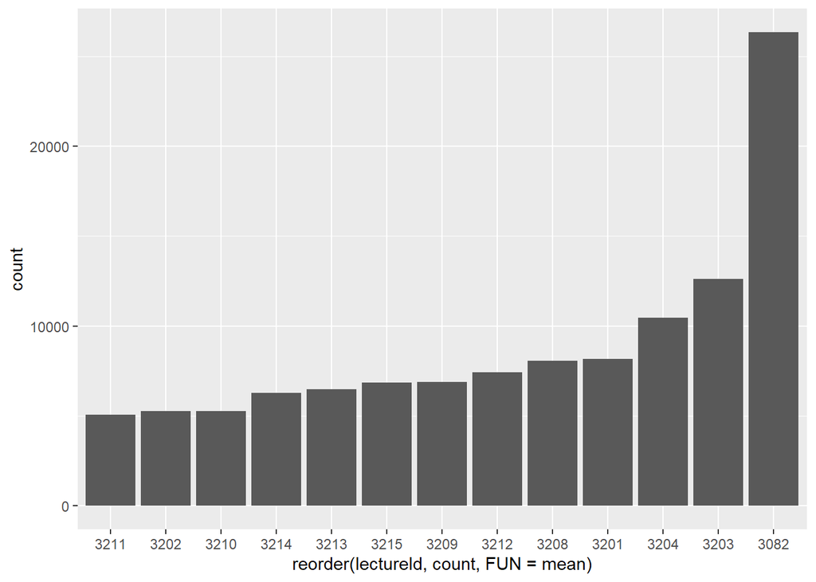

```r
hashAnswer %>% group_by(lectureId) %>% mutate("count" = n()) %>%
  ggplot(aes(x = reorder(lectureId, count, FUN = mean))) +
  geom_bar()
```

Gott að vita.